# Assignment 6: Parole Reform

- Show All Code
- Hide All Code
- View Source

MUSA 5080 · Fall 2026

Author

Luca Bushkin

Published

November 25, 2026

# The scenario

The Georgia Department of Community Supervision is considering a risk model to guide parole decisions. Every person released to parole would get a predicted probability of being **rearrested within three years**. The department has two proposed uses:

- **Use A:** people above a threshold get **more restrictive supervision** (more check-ins, electronic monitoring, faster revocation).
- **Use B:** people above a threshold get **priority for reentry services** (housing assistance, job placement, a case manager).

The department has promised that the model **will not use race**. You’ve been hired to build it and to tell them whether that promise means what they think it means.

**What you’re turning in:** this rendered document, published in the `assignments/` folder of your portfolio.

**How this assignment works:** it has less scaffolding than earlier ones. The **Week 11 lab** (COMPAS) is your fully worked example: almost every step here has a matching step there. Where the NIJ data behaves differently from COMPAS, the instructions below tell you. Everywhere else, adapt the lab code yourself.

| A6 part | Week 11 lab step |
| --- | --- |
| 3.1 odds ratios | Step 3 |
| 4.1 predictions + confusion matrix | Steps 4–5 |
| 4.3 threshold sweep | Step 5 (`rates_at()`) |
| 4.4 ROC + AUC | Step 6 |
| 5.1–5.2 errors by race | Step 7 |
| 5.3 what carries race in | Step 8 |

Two differences from the lab: the outcome is called **`recid`** (not `two_year_recid`), and you **fit on `train` and evaluate on `test`**. In the lab we fit and scored on the same data. So every `predict()` in Parts 4 and 5 needs `newdata = test`.

# The data

The National Institute of Justice’s **Recidivism Forecasting Challenge** data: 25,835 people released from Georgia prisons to parole supervision, 2013–2015. Download the CSV from Canvas, put it in your portfolio’s `data/` folder, and rename it `nij_recidivism.csv`.

A few things to know before you start:

- **Race is recorded only as Black or white.** The data includes no one else.
- **Counts are top-coded:** “10 or more” prior felony arrests is stored as text. `parse_number()` turns it into 10, which undercounts people with many more.
- **`Residence_PUMA`** is not a census PUMA code. NIJ grouped Georgia’s PUMAs into 25 areas and numbered them 1–25 to protect privacy. You can use it to group people by place, but you can’t map it.
- **`Training_Sample`** is NIJ’s own train/test split. Use it.

# Part 1: Load and clean

```r
library(tidyverse)

nij <- read_csv("C:/Users/lbush/Documents/UPenn Stuff/MUSA-5080-portfolio/assignments/assignment6_files/nij_recidivism.csv") %>%
  mutate(
    recid              = as.integer(Recidivism_Within_3years),
    male               = as.integer(Gender == "M"),
    age_group          = factor(Age_at_Release),
    prison_years       = factor(Prison_Years,
                                levels = c("Less than 1 year", "1-2 years",
                                           "Greater than 2 to 3 years",
                                           "More than 3 years")),
    prior_fel_arrests  = parse_number(Prior_Arrest_Episodes_Felony),
    prior_misd_arrests = parse_number(Prior_Arrest_Episodes_Misd),
    puma               = factor(Residence_PUMA)
  )

train <- nij %>% filter(Training_Sample == 1)
test  <- nij %>% filter(Training_Sample == 0)
```

**1.1** How many people are in `train` and in `test`? What share of each was rearrested within three years?

```r
nrow(train)
```

```
[1] 18028
```

```r
nrow(test)
```

```
[1] 7807
```

```r
train_recid <- train |>
  subset(recid == 1) |>
  count()

train_share <- train_recid / 18028

test_recid <- test |>
  subset(recid == 1) |>
  count()

test_share <- test_recid / 7807



df <- data.frame(
  Type = c("train", "test"),
  Count = c(18028, 7807),
  Recid = c(0.5780453, 0.5742283)
)

print(df)
```

```
   Type Count     Recid
1 train 18028 0.5780453
2  test  7807 0.5742283
```

*Your answer:* There are about 18,000 people in the training set and about 7,800 in the test set. Both sets have almost equal shares of recidivism (defined here as re-arrest within 3 years) of about 57%.

**1.2** Look at `Gang_Affiliated`. How many values are missing, and who are they? (Hint: cross-tabulate it with `Gender`.) What would happen to your sample if you added this variable to a model without handling the missing values?

```r
sum(is.na(nij$Gang_Affiliated))
```

```
[1] 3167
```

```r
women <- nij |>
  subset(Gender == "F")

sum(is.na(women$Gang_Affiliated))
```

```
[1] 3167
```

*Your answer:* None of the people classified as women have a gang affiliation listed. The model would not run if there are NAs for a predictor.

# Part 2: What would you know at the moment of decision?

The parole decision happens **at release**. Some columns in this file were recorded **during** the three years of supervision that followed.

**2.1** Sort every predictor column into one of two lists. You don’t need code; use `names(nij)` and the column names.

[output not shown]

**2.2** Pick one variable from the right-hand column and explain, in two sentences, why including it would make your model look better than it really is.

# Part 3: Build a race-blind model

Start from this model.

```r
base_fit <- glm(recid ~ male + age_group + prison_years +
                  prior_fel_arrests + prior_misd_arrests,
                family = binomial,
                data = train)

summary(base_fit)
```

```
Call:
glm(formula = recid ~ male + age_group + prison_years + prior_fel_arrests +
    prior_misd_arrests, family = binomial, data = train)

Coefficients:
                                       Estimate Std. Error z value Pr(>|z|)
(Intercept)                           -0.031637   0.078824  -0.401  0.68815
male                                   0.454123   0.049610   9.154  < 2e-16 ***
age_group23-27                        -0.505516   0.070835  -7.137 9.57e-13 ***
age_group28-32                        -1.062281   0.072975 -14.557  < 2e-16 ***
age_group33-37                        -1.448176   0.076123 -19.024  < 2e-16 ***
age_group38-42                        -1.678820   0.081802 -20.523  < 2e-16 ***
age_group43-47                        -1.910151   0.084204 -22.685  < 2e-16 ***
age_group48 or older                  -2.290828   0.080526 -28.448  < 2e-16 ***
prison_years1-2 years                 -0.124180   0.041760  -2.974  0.00294 **
prison_yearsGreater than 2 to 3 years -0.304194   0.049685  -6.122 9.22e-10 ***
prison_yearsMore than 3 years         -0.319948   0.047298  -6.765 1.34e-11 ***
prior_fel_arrests                      0.167507   0.006573  25.483  < 2e-16 ***
prior_misd_arrests                     0.131496   0.008719  15.081  < 2e-16 ***
---
Signif. codes:  0 '***' 0.001 '**' 0.01 '*' 0.05 '.' 0.1 ' ' 1

(Dispersion parameter for binomial family taken to be 1)

    Null deviance: 24551  on 18027  degrees of freedom
Residual deviance: 21940  on 18015  degrees of freedom
AIC: 21966

Number of Fisher Scoring iterations: 4
```

**3.1** Exponentiate the coefficients. Interpret the odds ratio for `prior_fel_arrests` in one sentence, using the word *odds* correctly.

```r
exp(base_fit$coefficients)
```

```
                          (Intercept)                                  male
                            0.9688582                             1.5747917
                       age_group23-27                        age_group28-32
                            0.6031942                             0.3456664
                       age_group33-37                        age_group38-42
                            0.2349986                             0.1865940
                       age_group43-47                  age_group48 or older
                            0.1480580                             0.1011826
                prison_years1-2 years prison_yearsGreater than 2 to 3 years
                            0.8832206                             0.7377176
        prison_yearsMore than 3 years                     prior_fel_arrests
                            0.7261868                             1.1823530
                   prior_misd_arrests
                            1.1405337
```

*Your answer:* People with prior felony arrests have an 18% increase in their odds of being rearrested than those without (holding all other variables equal).

**3.2** Constant on the odds, not on the probability. Use `predict(..., type = "response")` with `newdata` to compute the predicted probability for two made-up people, then add one prior felony arrest to each:

- a man, age 23–27, 1–2 years in prison, 2 prior felony arrests, 1 misdemeanor arrest
- a man, age 48 or older, 1–2 years in prison, 2 prior felony arrests, 1 misdemeanor arrest

How much does one more arrest change each person’s probability? Why are the two changes different?

```r
people <- tibble(
  male               = c(1, 1),
  age_group          = factor(c("23-27", "48 or older"), levels = levels(nij$age_group)),
  prison_years       = factor(c("1-2 years", "1-2 years"), levels = levels(nij$prison_years)),
  prior_fel_arrests  = c(2, 2),
  prior_misd_arrests = c(1, 1)
)

# your code here: predict for `people`, then for `people` with one more felony arrest
people <- people |>
  mutate(predict = predict(base_fit, newdata = people, type = "response"))

print(people)
```

```
# A tibble: 2 × 6
   male age_group   prison_years prior_fel_arrests prior_misd_arrests predict
  <dbl> <fct>       <fct>                    <dbl>              <dbl>   <dbl>
1     1 23-27       1-2 years                    2                  1   0.564
2     1 48 or older 1-2 years                    2                  1   0.179
```

```r
people1 <- tibble(
  male               = c(1, 1),
  age_group          = factor(c("23-27", "48 or older"), levels = levels(nij$age_group)),
  prison_years       = factor(c("1-2 years", "1-2 years"), levels = levels(nij$prison_years)),
  prior_fel_arrests  = c(3, 3),
  prior_misd_arrests = c(1, 1)
)

people1 <- people1 |>
  mutate(predict1 = predict(base_fit, newdata = people1, type = "response"))

print(people1)
```

```
# A tibble: 2 × 6
   male age_group   prison_years prior_fel_arrests prior_misd_arrests predict1
  <dbl> <fct>       <fct>                    <dbl>              <dbl>    <dbl>
1     1 23-27       1-2 years                    3                  1    0.605
2     1 48 or older 1-2 years                    3                  1    0.204
```

*Your answer:* One additional felony arrest increases the probability of rearrest by about 2-4%. Prior felony arrests have less of an impact on the probability of rearrest for people that are older.

**3.3** Improve the model. Add at least **three** predictors from your “known at release” list. Keep race out. Call it `my_fit`. In two or three sentences, say what you added and why you expected each one to help.

**WarningCheck for missing values before you add a variable**

Some columns have blanks: `Prison_Offense` is missing for about 1 in 8 people, and `Supervision_Level_First` for about 1 in 15. If you add one as it is, `glm()` **silently drops** those people from training, and `predict()` returns `NA` for them in `test`. Then `mean()` gives `NA` in Parts 4–6, and `table()` quietly leaves them out. Either leave the variable out, or keep the blanks as their own category, for example `mutate(offense = replace_na(Prison_Offense, "Missing"))`. Whichever you choose, say so in your answer.

```r
sum(is.na(nij$Education_Level))
```

```
[1] 0
```

```r
sum(is.na(nij$Prior_Conviction_Episodes_Viol))
```

```
[1] 0
```

```r
sum(is.na(nij$Prior_Arrest_Episodes_DVCharges))
```

```
[1] 0
```

```r
nij <- nij |>
  mutate(prior_convic_viol = as.integer(Prior_Conviction_Episodes_Viol == "TRUE"))

nij <- nij |>
  mutate(prior_arrest_DV = as.integer(Prior_Arrest_Episodes_DVCharges == "TRUE"))

train <- nij %>% filter(Training_Sample == 1)
test  <- nij %>% filter(Training_Sample == 0)

my_fit <- glm(recid ~ male + age_group + prison_years + prior_fel_arrests + prior_misd_arrests +
                Education_Level + prior_convic_viol + prior_arrest_DV,
                family = binomial,
                data = train)

summary(my_fit)
```

```
Call:
glm(formula = recid ~ male + age_group + prison_years + prior_fel_arrests +
    prior_misd_arrests + Education_Level + prior_convic_viol +
    prior_arrest_DV, family = binomial, data = train)

Coefficients:
                                       Estimate Std. Error z value Pr(>|z|)
(Intercept)                           -0.125672   0.085574  -1.469 0.141950
male                                   0.425040   0.050022   8.497  < 2e-16 ***
age_group23-27                        -0.508402   0.071065  -7.154 8.43e-13 ***
age_group28-32                        -1.062946   0.073507 -14.460  < 2e-16 ***
age_group33-37                        -1.451377   0.076881 -18.878  < 2e-16 ***
age_group38-42                        -1.674980   0.082930 -20.197  < 2e-16 ***
age_group43-47                        -1.905275   0.085413 -22.307  < 2e-16 ***
age_group48 or older                  -2.276689   0.081740 -27.853  < 2e-16 ***
prison_years1-2 years                 -0.138488   0.041899  -3.305 0.000949 ***
prison_yearsGreater than 2 to 3 years -0.325357   0.049894  -6.521 6.98e-11 ***
prison_yearsMore than 3 years         -0.348410   0.048209  -7.227 4.94e-13 ***
prior_fel_arrests                      0.163738   0.006640  24.660  < 2e-16 ***
prior_misd_arrests                     0.125275   0.008944  14.007  < 2e-16 ***
Education_LevelHigh School Diploma     0.219665   0.046596   4.714 2.43e-06 ***
Education_LevelLess than HS diploma    0.079612   0.048130   1.654 0.098106 .
prior_convic_viol                      0.132102   0.037528   3.520 0.000431 ***
prior_arrest_DV                        0.026263   0.047607   0.552 0.581188
---
Signif. codes:  0 '***' 0.001 '**' 0.01 '*' 0.05 '.' 0.1 ' ' 1

(Dispersion parameter for binomial family taken to be 1)

    Null deviance: 24551  on 18027  degrees of freedom
Residual deviance: 21897  on 18011  degrees of freedom
AIC: 21931

Number of Fisher Scoring iterations: 4
```

*Your answer:* I added education level, prior convictions of violence episodes, and prior arrests for domestic violence. I assumed that more violent episodes and especially arrests for domestic violence would increase the probability of rearrest. I assumed also that a lower education level would also be correlated with a higher probability of rearrest.

# Part 4: Choosing a threshold

**4.1** Add a column `p_hat` to `test` with predicted probabilities from `my_fit`, and a column `pred_50` that flags anyone at or above 0.5. (Parts 5 and 6 use these column names.) Then make a confusion matrix and compute sensitivity and specificity.

```r
test <- test|>
  mutate(p_hat = predict(my_fit, newdata = test, type = "response"))

test <- test |>
  mutate(pred_50 = as.integer(p_hat >= 0.5))

table(Predicted = test$pred_50, Actual = test$recid)
```

```
         Actual
Predicted    0    1
        0 1492  806
        1 1832 3677
```

```r
sensitivity <- 3677/(3677+806)

specificity <- 1492/(1492+1832)

sensitivity
```

```
[1] 0.8202097
```

```r
specificity
```

```
[1] 0.4488568
```

*Your answer:* Sensitivity is 0.82, while specificity is 0.45.

**4.2** What share of the test set does your model label “high risk” at 0.5? Compare it to the share actually rearrested. What does that tell you about 0.5 as a default for this data?

**4.3** Compute sensitivity and specificity for every threshold from 0.30 to 0.80 in steps of 0.05, and plot both lines on one chart with threshold on the x-axis.

Hint: in the lab you called `rates_at()` three times by hand. Here you need eleven thresholds. `map_dfr(thresholds, function(t) ...)` runs the same code once per threshold and stacks the results into one data frame. Your version will need `p_hat` instead of `pred`, and `recid` instead of `two_year_recid`.

```r
rates_at <- function(data, threshold) {
  data %>%
    mutate(flag = as.integer(p_hat >= threshold)) %>%
    summarize(
      threshold   = threshold,
      sensitivity = sum(flag == 1 & recid == 1) / sum(recid == 1),
      specificity = sum(flag == 0 & recid == 0) / sum(recid == 0),
      accuracy    = mean(flag == recid)
    )
}

threshold_table <- bind_rows(
  rates_at(test, 0.30),
  rates_at(test, 0.35),
  rates_at(test, 0.40),
  rates_at(test, 0.45),
  rates_at(test, 0.50),
  rates_at(test, 0.55),
  rates_at(test, 0.60),
  rates_at(test, 0.65),
  rates_at(test, 0.70),
  rates_at(test, 0.75),
  rates_at(test, 0.80)
)

threshold_table
```

```
# A tibble: 11 × 4
   threshold sensitivity specificity accuracy
       <dbl>       <dbl>       <dbl>    <dbl>
 1      0.3        0.963       0.184    0.632
 2      0.35       0.941       0.240    0.642
 3      0.4        0.912       0.299    0.651
 4      0.45       0.872       0.375    0.660
 5      0.5        0.820       0.449    0.662
 6      0.55       0.748       0.541    0.660
 7      0.6        0.647       0.644    0.646
 8      0.65       0.530       0.731    0.616
 9      0.7        0.393       0.836    0.582
10      0.75       0.255       0.904    0.531
11      0.8        0.130       0.961    0.484
```

```r
as.data.frame(threshold_table)
```

```
   threshold sensitivity specificity  accuracy
1       0.30   0.9634174   0.1841155 0.6316127
2       0.35   0.9406647   0.2400722 0.6423722
3       0.40   0.9116663   0.2987365 0.6506981
4       0.45   0.8715146   0.3751504 0.6601768
5       0.50   0.8202097   0.4488568 0.6620981
6       0.55   0.7481597   0.5409146 0.6599206
7       0.60   0.6471113   0.6435018 0.6455745
8       0.65   0.5297792   0.7313478 0.6156014
9       0.70   0.3932634   0.8360409 0.5817856
10      0.75   0.2545171   0.9040313 0.5310619
11      0.80   0.1296007   0.9608905 0.4835404
```

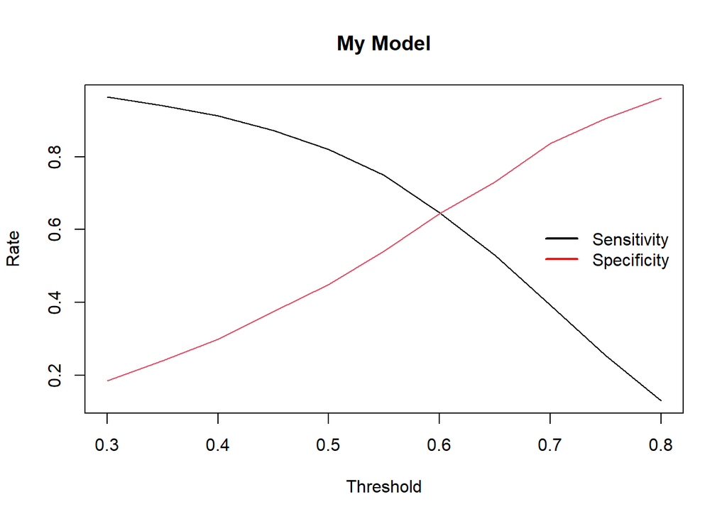

```r
plot(threshold_table$threshold,threshold_table$sensitivity, type = "l", col = 1,
     main = "My Model", xlab = "Threshold", ylab = "Rate")
lines(threshold_table$threshold, threshold_table$specificity, type = "l", col = 2)
legend("right",
       legend = c("Sensitivity", "Specificity"),
       inset = 0.01,
       box.lty = 0,
       col = c("black", "red"),
       lty = c(1, 1),
       lwd = 2)
```

**4.4** Plot the ROC curve for `my_fit` on the test set with `pROC` and report the AUC. In one sentence: what does the AUC tell you, and what doesn’t it tell you about the decision the department has to make?

```r
library(pROC)

roc_obj <- roc(test$recid, test$p_hat)

auc(roc_obj)
```

```
Area under the curve: 0.6994
```

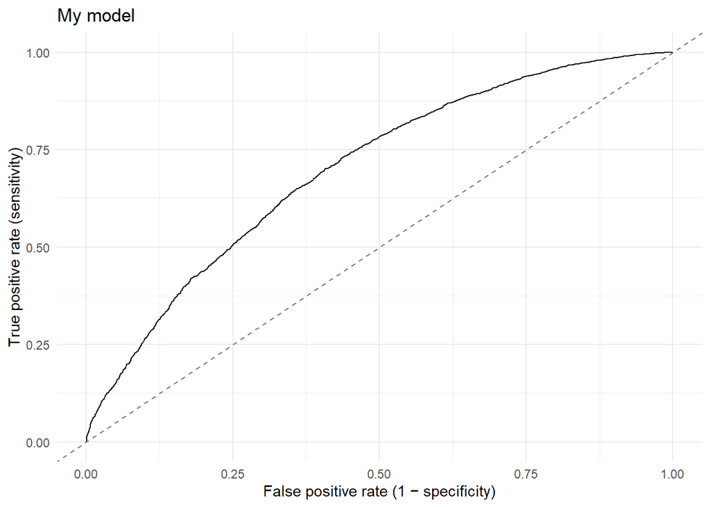

```r
ggroc(roc_obj, legacy.axes = TRUE) +
  geom_abline(linetype = "dashed", color = "grey50") +
  labs(x = "False positive rate (1 − specificity)",
       y = "True positive rate (sensitivity)",
       title = "My model") +
  theme_minimal()
```

*Your answer:* The AUC for my model is about 0.70. This AUC suggests that my model is decently good at classifying the observations (although it could be better). However, the AUC does not tell us which threshold to use.

# Part 5: Is it race-blind?

Race isn’t in your model. Now check the errors by race on the **test set**.

**5.1** At the threshold of 0.5, compute for each race: the share labeled high risk, the share actually rearrested, the **false positive rate** (labeled high risk, not rearrested, out of everyone not rearrested), and the **false negative rate**.

```r
white_test <- test|>
  subset(Race == "WHITE")

black_test <- test|>
  subset(Race == "BLACK")

table(Predicted = white_test$pred_50, Actual = white_test$recid)
```

```
         Actual
Predicted    0    1
        0  721  366
        1  706 1480
```

```r
white_fpr = 706/(721+706)
white_fnr = 366/(1480+366)

table(Predicted = black_test$pred_50, Actual = black_test$recid)
```

```
         Actual
Predicted    0    1
        0  771  440
        1 1126 2197
```

```r
black_fpr = 1126/(771+1126)
black_fnr = 440/(2197+440)

race_test <- tibble(
  race           = c("White", "Black"),
  fpr            = c(white_fpr, black_fpr),
  fnr            = c(white_fnr, black_fnr),
)

print(race_test)
```

```
# A tibble: 2 × 3
  race    fpr   fnr
  <chr> <dbl> <dbl>
1 White 0.495 0.198
2 Black 0.594 0.167
```

**5.2** Repeat 5.1 at two other thresholds from your sweep. Does the gap between groups close, stay, or flip?

```r
#threshold of 0.4

test <- test |>
  mutate(pred_40 = as.integer(p_hat >= 0.4))

white_0.4 <- test|>
  subset(Race == "WHITE")

black_0.4 <- test|>
  subset(Race == "BLACK")

table(Predicted = white_0.4$pred_40, Actual = white_0.4$recid)
```

```
         Actual
Predicted    0    1
        0  506  189
        1  921 1657
```

```r
white_fpr4 = 921/(921+506)
white_fnr4 = 189/(189+1657)

table(Predicted = black_0.4$pred_40, Actual = black_0.4$recid)
```

```
         Actual
Predicted    0    1
        0  487  207
        1 1410 2430
```

```r
black_fpr4 = 1410/(1410+487)
black_fnr4 = 207/(207+2430)

race_0.4 <- tibble(
  race           = c("White", "Black"),
  fpr_0.4        = c(white_fpr4, black_fpr4),
  fnr_0.4         = c(white_fnr4, black_fnr4),
)


#threshold 0.6

test <- test |>
  mutate(pred_60 = as.integer(p_hat >= 0.6))

white_0.6 <- test|>
  subset(Race == "WHITE")

black_0.6 <- test|>
  subset(Race == "BLACK")

table(Predicted = white_0.6$pred_60, Actual = white_0.6$recid)
```

```
         Actual
Predicted    0    1
        0  963  690
        1  464 1156
```

```r
white_fpr6 = 464/(464+963)
white_fnr6 = 690/(690+1156)

table(Predicted = black_0.6$pred_60, Actual = black_0.6$recid)
```

```
         Actual
Predicted    0    1
        0 1176  892
        1  721 1745
```

```r
black_fpr6 = 721/(721+1176)
black_fnr6 = 892/(892+1745)

race_0.6 <- tibble(
  race           = c("White", "Black"),
  fpr_0.6        = c(white_fpr6, black_fpr6),
  fnr_0.6        = c(white_fnr6, black_fnr6),
)

print(race_0.4)
```

```
# A tibble: 2 × 3
  race  fpr_0.4 fnr_0.4
  <chr>   <dbl>   <dbl>
1 White   0.645  0.102
2 Black   0.743  0.0785
```

```r
print(race_0.6)
```

```
# A tibble: 2 × 3
  race  fpr_0.6 fnr_0.6
  <chr>   <dbl>   <dbl>
1 White   0.325   0.374
2 Black   0.380   0.338
```

*Your answer:* At a lower threshold (below 0.5), the gap in false positive rates between races stays about the same, while at a higher threshold (above 0.5), the gap becomes slightly smaller. The inverse is true for false negative rates.

**5.3** Investigate at least two candidates by comparing their distributions by race. Possibilities include age, prior arrests, prison offense, and place (`puma`). Show your evidence with a table or chart for each.

```r
people_2 <- test |>
  subset(male == 1 &
           age_group == "18-22" &
           prison_years == "1-2 years" &
           prior_fel_arrests == 1 &
           prior_misd_arrests == 1 &
           Education_Level == "High School Diploma" &
           prior_convic_viol == 1 &
           prior_arrest_DV == 0)

people_2 <- people_2 |>
  select(Gender, Race, age_group, prison_years, prior_fel_arrests, prior_misd_arrests, Education_Level, prior_convic_viol, prior_arrest_DV, recid, p_hat, pred_50, pred_40, pred_60)

people_2
```

```
# A tibble: 2 × 14
  Gender Race  age_group prison_years prior_fel_arrests prior_misd_arrests
  <chr>  <chr> <fct>     <fct>                    <dbl>              <dbl>
1 M      BLACK 18-22     1-2 years                    1                  1
2 M      WHITE 18-22     1-2 years                    1                  1
# ℹ 8 more variables: Education_Level <chr>, prior_convic_viol <int>,
#   prior_arrest_DV <int>, recid <int>, p_hat <dbl>, pred_50 <int>,
#   pred_40 <int>, pred_60 <int>
```

*Your answer:* In this example, these two people had the same inputs for each of the variables included in my model. They were both predicted as “high-risk,” despite not being rearrested.

# Part 6: Does it hold up in places it hasn’t seen?

Use leave-one-PUMA-group-out cross-validation **on the training set**, the same recipe as Week 10’s leave-one-district-out.

```r
pumas <- levels(train$puma)

cv_puma <- map_dfr(pumas, function(u) {
  cv_train <- train %>% filter(puma != u)
  cv_test  <- train %>% filter(puma == u)

  fit <- glm(formula(my_fit), family = binomial, data = cv_train)

  cv_test %>%
    mutate(pred = as.integer(predict(fit, newdata = cv_test,
                                     type = "response") >= 0.5)) %>%
    summarize(puma       = u,
              n          = n(),
              share_black = mean(Race == "BLACK"),
              accuracy   = mean(pred == recid),
              fpr        = sum(pred == 1 & recid == 0) / sum(recid == 0))
})
```

**6.1** Plot each PUMA group’s false positive rate against its share of Black parolees. What pattern, if any, do you see?

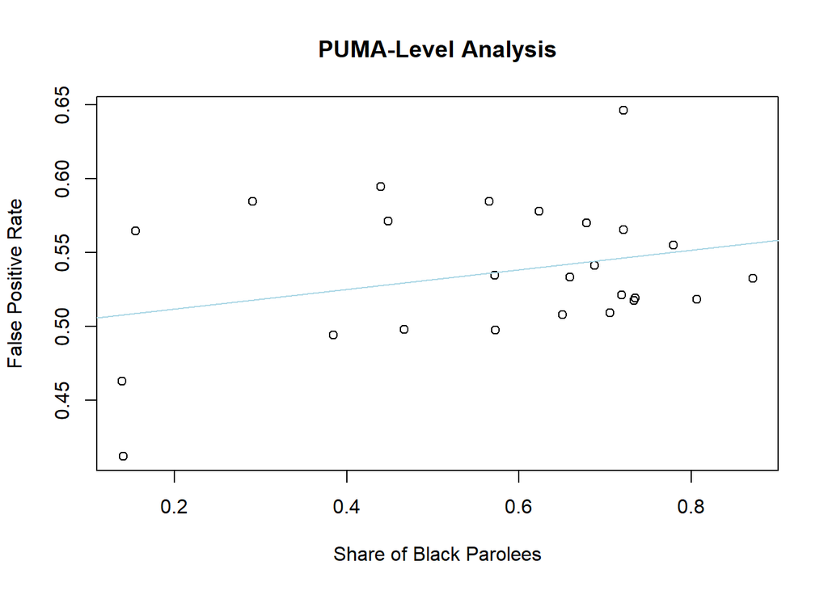

```r
plot(cv_puma$share_black, cv_puma$fpr,
     main = "PUMA-Level Analysis", xlab = "Share of Black Parolees", ylab = "False Positive Rate")
abline(lm(cv_puma$fpr ~ cv_puma$share_black), col = "lightblue")
```

*Your answer:* PUMA areas with higher shares of Black parolees tend to see a higher false positive rate with my current model.

**6.2** If you put `puma` itself into the model as a predictor, would that make the model more or less race-blind? Make an argument using what you found in 6.1. (You may test it, but you don’t have to.)

*Your answer:* Using the PUMA code itself instead of the share of Black parolees would not change how race-blind the model is (or is not). This is because each PUMA area has embedded in it race as a demographic element.

# Part 7: The memo

Write a memo (**400–600 words**) to the Department of Community Supervision. It must:

1. **Pick a threshold for Use A and a threshold for Use B**, and defend each using the cost of a false positive and a false negative *in that use*. Cite your own numbers from Parts 4 and 5.
2. Tell them **whether “the model doesn’t use race” means it treats Black and white parolees the same**, using your Part 5 results.
3. End with one sentence: **“I would / would not deploy this for Use *, unless* .”**

Write to a deputy commissioner, not to a statistician. No code, no jargon you haven’t explained.

*Your memo:*

Dear Deputy Commissioner of the Department of Community Supervision,

This memo outlines a model for predicting recidivism using 2013–2015 data from the National Institute of Justice. The model uses a mixture of demographic and criminal history data as inputs for predicting the likelihood of rearrest within three years of release. The model’s performance varies based on a given threshold, however.

In sum, I would not deploy this model for either Use A or Use B unless some kind of weight was added to account for the discrepancies between races.